Using 20 years of daily high temperature data for Atlanta (July through October), building an exponential smoothing model

```r
rm(list=ls())
set.seed(1)
```

```r
#import data
temp <-read.table("temps.txt", stringsAsFactors = FALSE, header = TRUE)
head(temp)
```

```
##     DAY X1996 X1997 X1998 X1999 X2000 X2001 X2002 X2003 X2004 X2005 X2006 X2007
## 1 1-Jul    98    86    91    84    89    84    90    73    82    91    93    95
## 2 2-Jul    97    90    88    82    91    87    90    81    81    89    93    85
## 3 3-Jul    97    93    91    87    93    87    87    87    86    86    93    82
## 4 4-Jul    90    91    91    88    95    84    89    86    88    86    91    86
## 5 5-Jul    89    84    91    90    96    86    93    80    90    89    90    88
## 6 6-Jul    93    84    89    91    96    87    93    84    90    82    81    87
##   X2008 X2009 X2010 X2011 X2012 X2013 X2014 X2015
## 1    85    95    87    92   105    82    90    85
## 2    87    90    84    94    93    85    93    87
## 3    91    89    83    95    99    76    87    79
## 4    90    91    85    92    98    77    84    85
## 5    88    80    88    90   100    83    86    84
## 6    82    87    89    90    98    83    87    84
```

```r
tail(temp)
```

```
##        DAY X1996 X1997 X1998 X1999 X2000 X2001 X2002 X2003 X2004 X2005 X2006
## 118 26-Oct    75    71    79    69    75    64    68    68    79    61    62
## 119 27-Oct    75    57    79    75    78    51    69    64    81    63    66
## 120 28-Oct    81    55    79    73    80    55    75    57    78    62    63
## 121 29-Oct    82    64    78    72    75    63    75    70    75    64    72
## 122 30-Oct    82    66    82    75    77    72    68    77    78    69    73
## 123 31-Oct    81    60    79    75    78    71    60    75    82    70    68
##     X2007 X2008 X2009 X2010 X2011 X2012 X2013 X2014 X2015
## 118    68    70    65    85    77    80    61    84    67
## 119    67    59    60    76    79    70    69    84    56
## 120    70    50    71    74    74    56    64    77    78
## 121    62    59    75    68    59    56    75    73    70
## 122    67    65    66    71    61    56    78    68    70
## 123    71    67    69    75    65    65    74    63    62
```

```r
str(temp)
```

```
## 'data.frame':    123 obs. of  21 variables:
##  $ DAY  : chr  "1-Jul" "2-Jul" "3-Jul" "4-Jul" ...
##  $ X1996: int  98 97 97 90 89 93 93 91 93 93 ...
##  $ X1997: int  86 90 93 91 84 84 75 87 84 87 ...
##  $ X1998: int  91 88 91 91 91 89 93 95 95 91 ...
##  $ X1999: int  84 82 87 88 90 91 82 86 87 87 ...
##  $ X2000: int  89 91 93 95 96 96 96 91 96 99 ...
##  $ X2001: int  84 87 87 84 86 87 87 89 91 87 ...
##  $ X2002: int  90 90 87 89 93 93 89 89 90 91 ...
##  $ X2003: int  73 81 87 86 80 84 87 90 89 84 ...
##  $ X2004: int  82 81 86 88 90 90 89 87 88 89 ...
##  $ X2005: int  91 89 86 86 89 82 76 88 89 78 ...
##  $ X2006: int  93 93 93 91 90 81 80 82 84 84 ...
##  $ X2007: int  95 85 82 86 88 87 82 82 89 86 ...
##  $ X2008: int  85 87 91 90 88 82 88 90 89 87 ...
##  $ X2009: int  95 90 89 91 80 87 86 82 84 84 ...
##  $ X2010: int  87 84 83 85 88 89 94 97 96 90 ...
##  $ X2011: int  92 94 95 92 90 90 94 94 91 92 ...
##  $ X2012: int  105 93 99 98 100 98 93 95 97 95 ...
##  $ X2013: int  82 85 76 77 83 83 79 88 88 87 ...
##  $ X2014: int  90 93 87 84 86 87 89 90 90 87 ...
##  $ X2015: int  85 87 79 85 84 84 90 90 91 93 ...
```

[output not shown]

Create data into time series

1. First changing from dataframe/matrix set up to one long list of vectors using unlist.

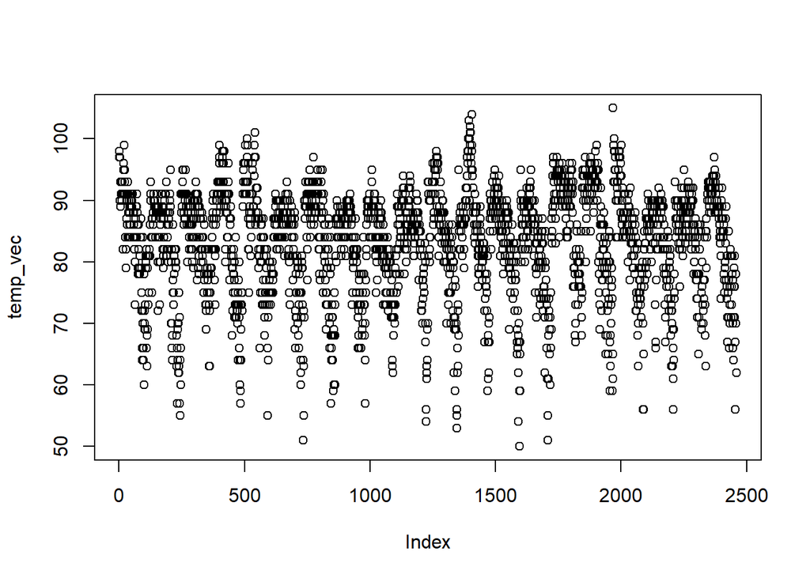

```r
temp_vec <- as.vector(unlist(temp[,2:21]))
#temp_vec
plot(temp_vec)
```

2. Changing the long vectors just created to time series by starting at 1996 and repeating it every 123 observation until 2015

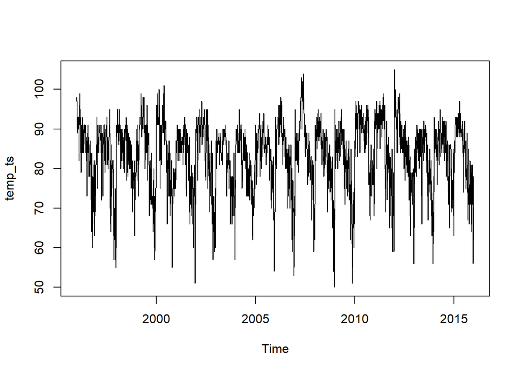

```
Plotting the timeseries data, we realize that temp is fairy consistent in the range 70-90 with avg around 80. It has some level of seasonality with some seasonal peaks and valleys which do not look same overtime.
```

```r
#?ts

temp_ts <- ts(temp_vec, start=1996, frequency=123)
plot(temp_ts)
```

Now, viewing the components of the time series data separately to get a better understanding using ‘decompose’

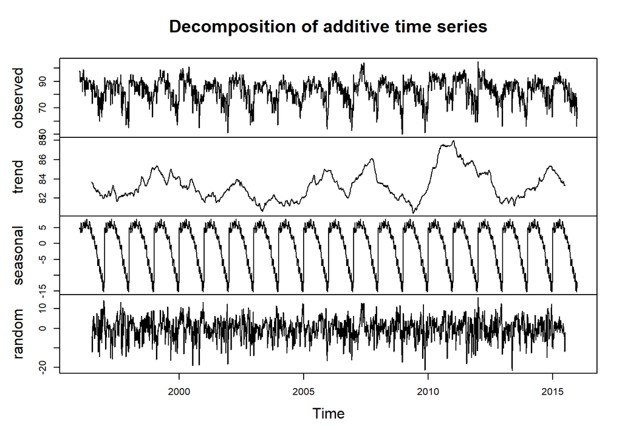

[output not shown]

```r
#?decompose
plot(decompose(temp_ts))
```

Breakdown into exponential smoothing - single (without any trend or seasonality), double and triple smoothing.

```r
#1 single exponential smoothing WITH NO TREND nOR seasonality
#not including trend (beta) and seasonality (gamma) i.e., FALSE
#Leaving the alpha (level) and beta (trend) parameters as null allows the function to identify optimal parameters

single_expo <- HoltWinters(temp_ts,beta=FALSE,gamma=FALSE)
single_expo
```

```
## Holt-Winters exponential smoothing without trend and without seasonal component.
##
## Call:
## HoltWinters(x = temp_ts, beta = FALSE, gamma = FALSE)
##
## Smoothing parameters:
##  alpha: 0.8388021
##  beta : FALSE
##  gamma: FALSE
##
## Coefficients:
##       [,1]
## a 63.30952
```

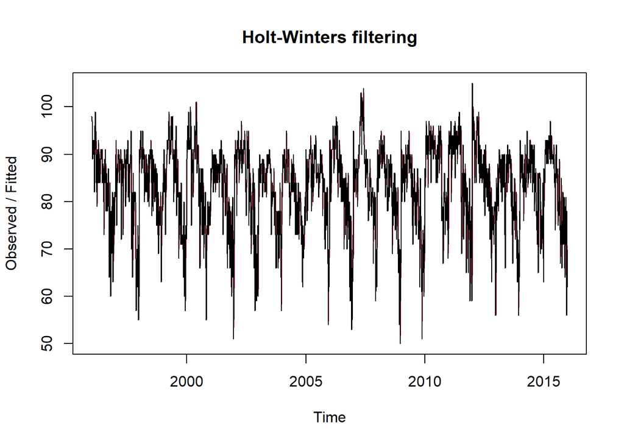

```r
plot(single_expo)
```

```r
#double exponential smoothing
## Holt-Winters exponential smoothing with trend and without seasonal component.
double_expo <- HoltWinters(temp_ts,gamma=FALSE)
double_expo
```

```
## Holt-Winters exponential smoothing with trend and without seasonal component.
##
## Call:
## HoltWinters(x = temp_ts, gamma = FALSE)
##
## Smoothing parameters:
##  alpha: 0.8445729
##  beta : 0.003720884
##  gamma: FALSE
##
## Coefficients:
##         [,1]
## a 63.2530022
## b -0.0729933
```

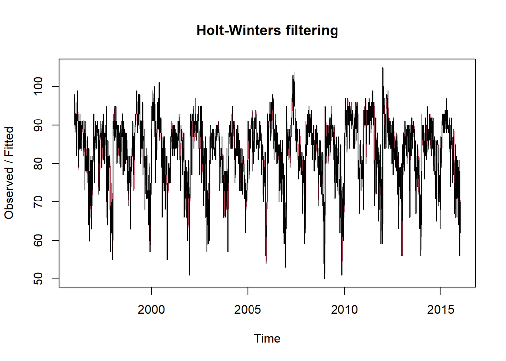

```r
plot(double_expo)
```

```r
# Triple exponential smoothing (includes both trend and seasonality)

triple_expo <- HoltWinters(temp_ts)
triple_expo
```

```
## Holt-Winters exponential smoothing with trend and additive seasonal component.
##
## Call:
## HoltWinters(x = temp_ts)
##
## Smoothing parameters:
##  alpha: 0.6610618
##  beta : 0
##  gamma: 0.6248076
##
## Coefficients:
##               [,1]
## a     71.477236414
## b     -0.004362918
## s1    18.590169842
## s2    17.803098732
## s3    12.204442890
## s4    13.233948865
## s5    12.957258705
## s6    11.525341233
## s7    10.854441534
## s8    10.199632666
## s9     8.694767348
## s10    5.983076192
## s11    3.123493477
## s12    4.698228193
## s13    2.730023168
## s14    2.995935818
## s15    1.714600919
## s16    2.486701224
## s17    6.382595268
## s18    5.081837636
## s19    7.571432660
## s20    6.165047647
## s21    9.560458487
## s22    9.700133847
## s23    8.808383245
## s24    8.505505527
## s25    7.406809208
## s26    6.839204571
```

[output cut: 82 more lines]

```
## s109 -11.921434142
## s110 -12.035411347
## s111 -12.837047727
## s112  -9.095808127
## s113  -5.433029341
## s114  -6.800835107
## s115  -8.413639598
## s116 -10.912409484
## s117 -13.553826535
## s118 -10.652543677
## s119 -12.627298331
## s120  -9.906981556
## s121 -12.668519900
## s122  -9.805502547
## s123  -7.775306633
```